# Assignment 6

Author

Hanif Kawousi

Published

December 10, 2023

```r
library(tidyverse)
library(conflicted) #although part of tidyverse, I could not render the qmd-file unless I loaded it.
library(here)
library(survival)
library(gt)
library(survminer)
library(ggfortify)
library(performance)
library(lme4)
library(lmerTest)
library(effects)
library(finalfit)
library(broom.mixed)
```

```r
#- status : farmed or wild area
#- exp : which room the salmon were raised in.
#- origin : geographic area. B: Austevoll; F: Frøya; O: Oslofjord ; S: Scotland
#- tank2 : combination of exp and tank
#- tank : which tank the salmon were raised in.
#- daysPI : days post-infection of the lice on the salmon that eggs were produced.
#- ES : reproductive event. We are only intesum_fitted in the first event
conflicts_prefer(dplyr::filter)

data <- read.table(file = here(
  "Desktop/BIO300B/assignment_6/timing_ES1to5.txt"
  ), header = TRUE) |>
  janitor::clean_names() |>
  filter(es == 1) |>
  mutate(status = if_else(status == "farmed", 0, 1))

#Regarding column "Status": Farmed = 0 and Wild = 1. This is done due to survival analysis later,
# where we want numerical values.
```

### 1. Fit a suitable model to test the hypothesis and examine any diagnostics.

```r
conflicts_prefer(lme4::lmer)

#Creating a survival object.
surv_obj <- Surv(data$days_pi, data$es)

#Cox Proportional Hazards Model: http://www.sthda.com/english/wiki/cox-proportional-hazards-model
model <- coxph(surv_obj ~ status + origin + exp + (1|tank), data = data)
```

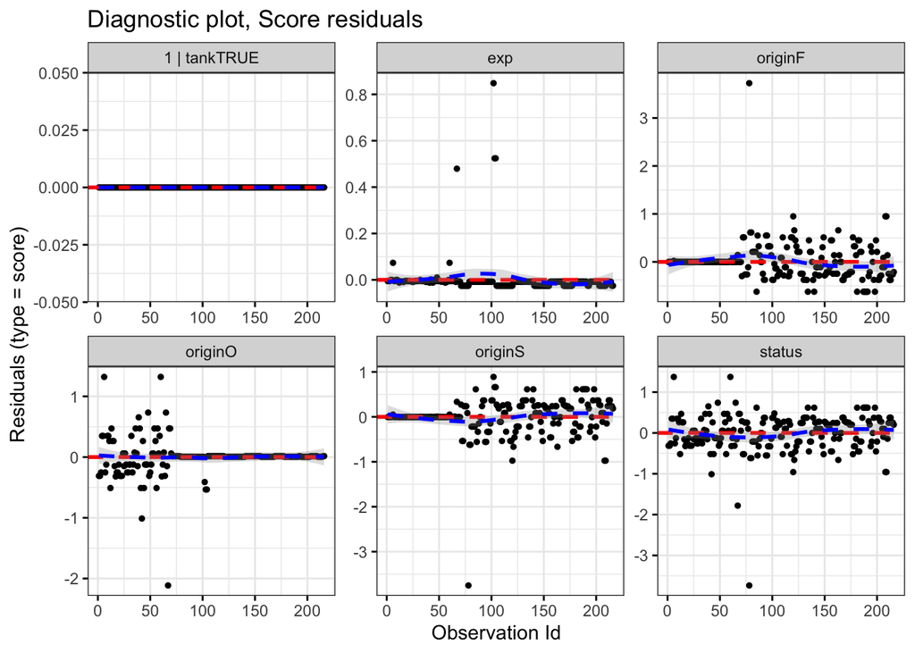

```r
ggcoxdiagnostics(model, type = "score", title = "Diagnostic plot, Score residuals")
```

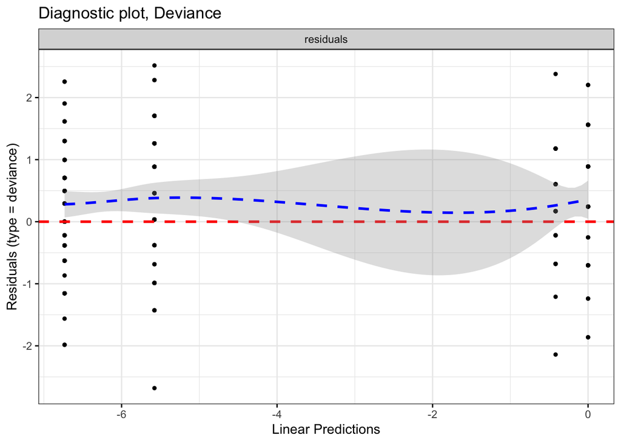

```r
ggcoxdiagnostics(model, type = "deviance", title = "Diagnostic plot, Deviance")
```

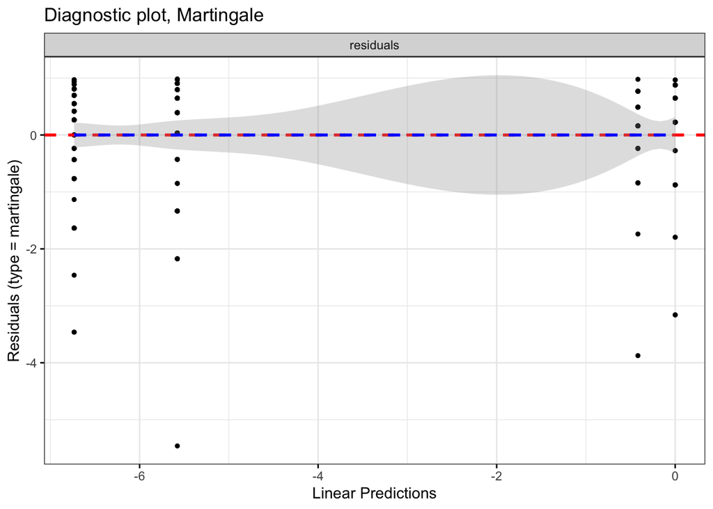

```r
ggcoxdiagnostics(model, type = "martingale", title = "Diagnostic plot, Martingale")
```

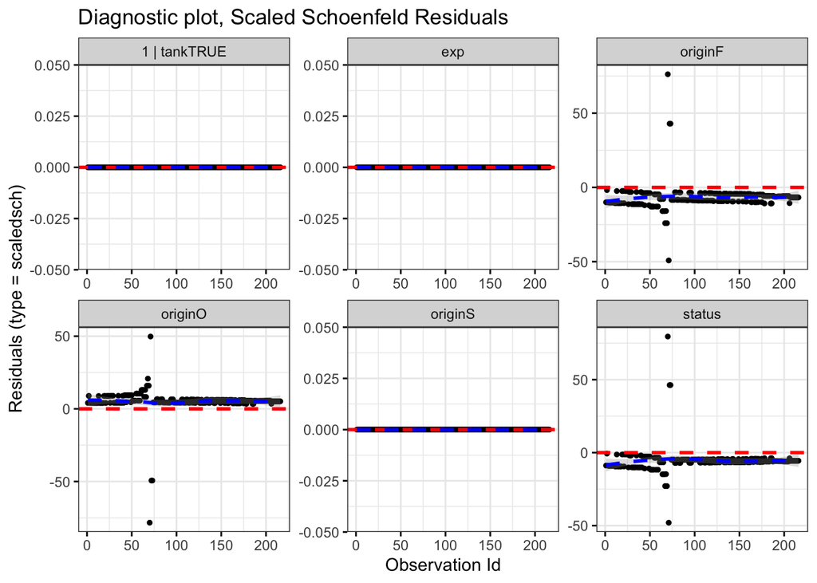

```r
ggcoxdiagnostics(model, type = "scaledsch", title = "Diagnostic plot, Scaled Schoenfeld Residuals") #should be aligned with "zero".
```

### 2. Make a publication-ready plot of the data and the model results

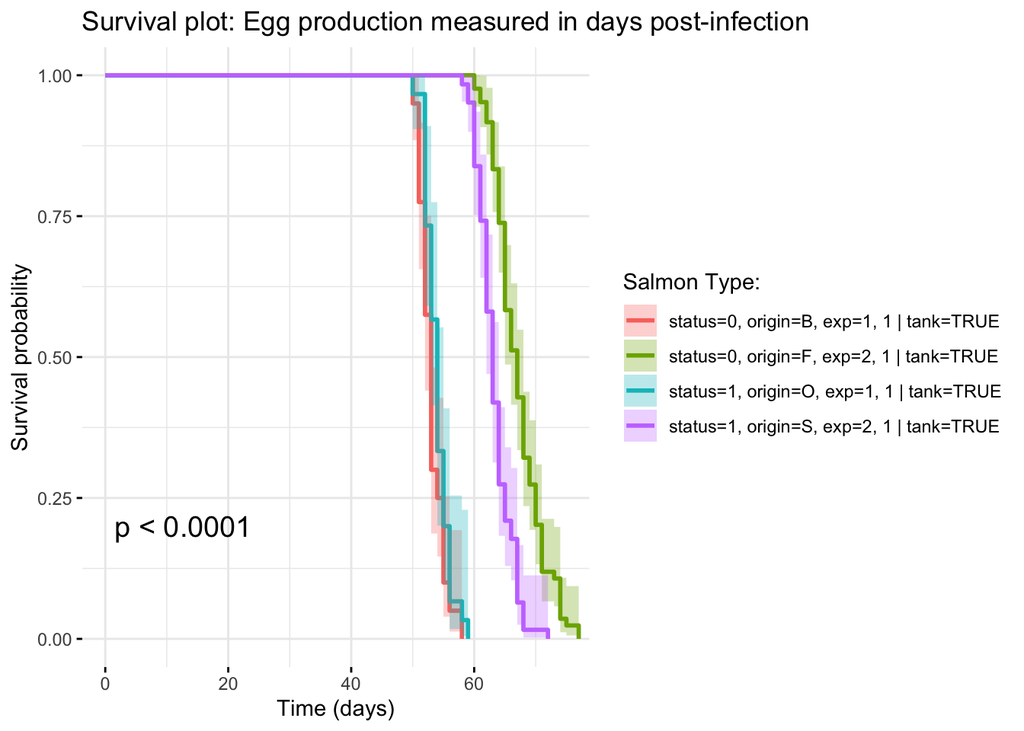

```r
# Fit the survival model
fit <- survfit(surv_obj ~ status + origin + exp + (1|tank), data = data)

# Plot the Kaplan-Meier curves
ggsurvplot(fit,
          data = data,
          conf.in = TRUE,
          pval = TRUE,
          risk.table = FALSE,
          survival.table = TRUE,
          legend = "right",
          legend.title = "Salmon Type:",
          xlab = "Time (days)",
          title = "Survival plot: Egg production measured in days post-infection",
          ggtheme = theme_minimal() +
              theme(legend.position = "right",
                   plot.title = element_text(hjust = 0))
          )
```

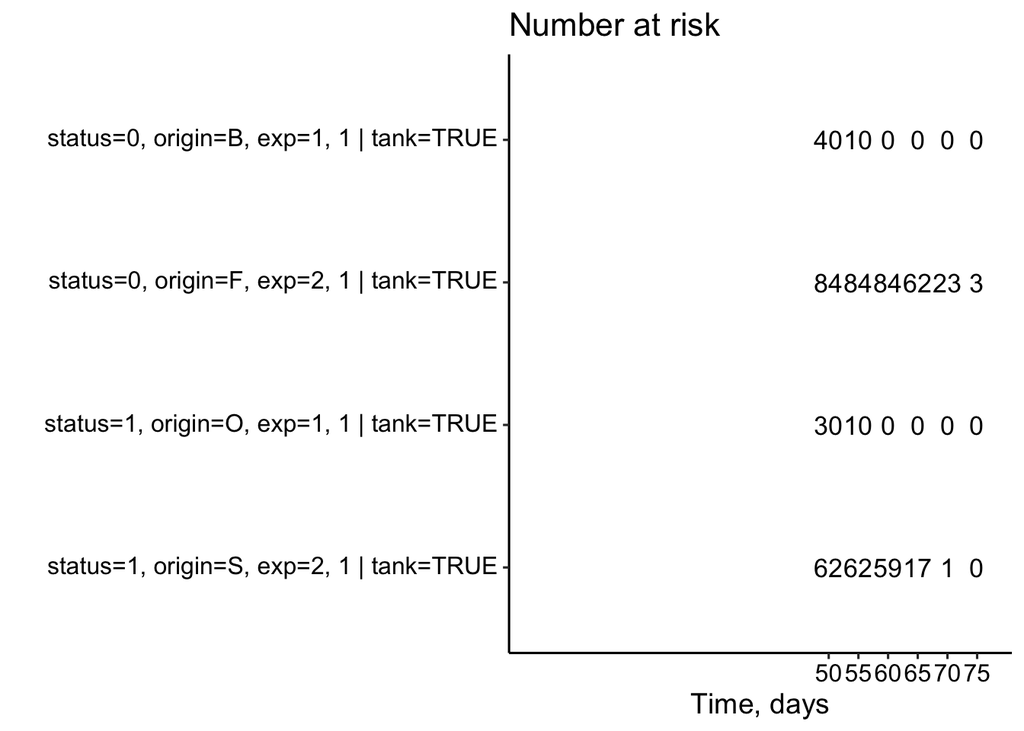

As we can more clearly see from the Kaplan-Meier-Curves accompanying risk-table, it is clear that the “exp”, meaning the room the salmon were raised in has the dominating significant impact on the event measured.

```r
# Plot the risk table
risk_table <- ggrisktable(fit,
                          data = data,
                          #color = "strata",
                          y.text = TRUE,
                          ylab = "",
                          xlab = "Time, days",
                          colour = "strata"
                          )

# Print the risk table
print(risk_table)
```

### Answer to: 4. Critique the experimental design and your model.

The effects of “exp” (the room of which the salmon where placed in) is the only variable that can explain the massive difference between the wild-type and the farm-type, regardless of origin. In other words, based on the data, the most significant effect on the salmon were the rooms they were raised in, and not the intervention of the experimental design. This is not mentioned clearly in the article the assignment is based on. Even if it did not matter for the overarching result where all reproductive events are included, this is a significant weakness of the experiment and absolutely worth making a deal out of.

The model is from what is shown in the diagnostic plots, not too bad. The score-residual plots are showing dots scattered somewhat around zero, enforces by their blue, stipled line. The residual values are not linear, which could be explained by the effects of the above-mentioned faulty experimental design. However the Martingale-plot looks very promising. Looking further at the plots “Scaled Schoenfeld Residuals”, there are some devianses. Not all are aligned with “zero” (“origin F”, “origin O” and “status”). Perhaps this means that there could have been benefits to using another model like lmer. However, the coxph-model is typically used with survival-analyses and that is also the reason why I chose it. Lastly, the benefit of using this model is that it handles many types of depented variables well, as well as random intercepts.

### 3. Report your model results either in a publishable table or in a short paragraph.

```r
model_tidy <- tidy(model)

model_tidy <- model_tidy |>
 mutate(term = ifelse(term == "status", "originB", term))

# Create the gt table
gt_table <- gt(model_tidy) |>
 cols_label(term = "Term",
            std.error = "Std.Error",
            statistic = "T.val",
            p.value = "P.val") |>
 fmt_number(decimals = 3) |>
  tab_header(title = md("COXPH-model data"))

gt_table
```

Values produces by the cox proportional hazards model.

COXPH-model data

| Term | estimate | Std.Error | T.val | P.val |
| --- | --- | --- | --- | --- |
| originB | −5.577 | 0.689 | −8.097 | 0.000 |
| originF | −6.733 | 0.698 | −9.640 | 0.000 |
| originO | 5.159 | 0.677 | 7.616 | 0.000 |
| originS | NA | 0.000 | NA | NA |
| exp | NA | 0.000 | NA | NA |
| 1 \| tankTRUE | NA | 0.000 | NA | NA |

### Another table for exploratory reasons due to the NAs in the previous table.

For some reason beyond me, I can’t figure out why I get the NAs in the table above. Creating additional table with more details.

```r
# Extracting the summary table
sum_fit <- summary(fit, time = seq(30, 80, 3))


# Converting the summary table into a data frame
tbl <- data.frame(category = sum_fit$strata,
                  time = sum_fit$time,
              n.risk = sum_fit$n.risk,
              n.event = sum_fit$n.event,
              n.censor = sum_fit$n.censor,
              surv = sum_fit$surv,
              std.err = sum_fit$std.err,
              upper = sum_fit$upper,
              lower = sum_fit$lower,
              conf.int = sum_fit$conf.int)

# Creating a gt table
gt_tbl <- gt(tbl)

# Customizing the table
gt_tbl <- gt_tbl |>
 tab_header(
   title = "Survival Analysis",
   subtitle = "Survival Probabilities at Different Time Points"
 ) |>
 fmt_number(columns = c("n.risk", "n.event", "n.censor"), decimals = 0) |>
 fmt_percent(columns = c("surv", "upper", "lower")) |>
 fmt_number(columns = c("std.err", "conf.int"), decimals = 2) |>
 tab_options(
   table.font.size = "small",
   data_row.padding = px(1)
 )

#the final table for print:
gt_tbl
```

Survival Analysis

Survival Probabilities at Different Time Points

| category | time | n.risk | n.event | n.censor | surv | std.err | upper | lower | conf.int |
| --- | --- | --- | --- | --- | --- | --- | --- | --- | --- |
| status=0, origin=B, exp=1, 1 \| tank=TRUE | 30 | 40 | 0 | 0 | 100.00% | 0.00 | 100.00% | 100.00% | 0.95 |
| status=0, origin=B, exp=1, 1 \| tank=TRUE | 33 | 40 | 0 | 0 | 100.00% | 0.00 | 100.00% | 100.00% | 0.95 |
| status=0, origin=B, exp=1, 1 \| tank=TRUE | 36 | 40 | 0 | 0 | 100.00% | 0.00 | 100.00% | 100.00% | 0.95 |
| status=0, origin=B, exp=1, 1 \| tank=TRUE | 39 | 40 | 0 | 0 | 100.00% | 0.00 | 100.00% | 100.00% | 0.95 |
| status=0, origin=B, exp=1, 1 \| tank=TRUE | 42 | 40 | 0 | 0 | 100.00% | 0.00 | 100.00% | 100.00% | 0.95 |
| status=0, origin=B, exp=1, 1 \| tank=TRUE | 45 | 40 | 0 | 0 | 100.00% | 0.00 | 100.00% | 100.00% | 0.95 |
| status=0, origin=B, exp=1, 1 \| tank=TRUE | 48 | 40 | 0 | 0 | 100.00% | 0.00 | 100.00% | 100.00% | 0.95 |
| status=0, origin=B, exp=1, 1 \| tank=TRUE | 51 | 38 | 9 | 0 | 77.50% | 0.07 | 91.58% | 65.58% | 0.95 |
| status=0, origin=B, exp=1, 1 \| tank=TRUE | 54 | 12 | 21 | 0 | 25.00% | 0.07 | 42.76% | 14.62% | 0.95 |
| status=0, origin=B, exp=1, 1 \| tank=TRUE | 57 | 2 | 8 | 0 | 5.00% | 0.03 | 19.30% | 1.30% | 0.95 |
| status=0, origin=F, exp=2, 1 \| tank=TRUE | 30 | 84 | 0 | 0 | 100.00% | 0.00 | 100.00% | 100.00% | 0.95 |
| status=0, origin=F, exp=2, 1 \| tank=TRUE | 33 | 84 | 0 | 0 | 100.00% | 0.00 | 100.00% | 100.00% | 0.95 |
| status=0, origin=F, exp=2, 1 \| tank=TRUE | 36 | 84 | 0 | 0 | 100.00% | 0.00 | 100.00% | 100.00% | 0.95 |
| status=0, origin=F, exp=2, 1 \| tank=TRUE | 39 | 84 | 0 | 0 | 100.00% | 0.00 | 100.00% | 100.00% | 0.95 |
| status=0, origin=F, exp=2, 1 \| tank=TRUE | 42 | 84 | 0 | 0 | 100.00% | 0.00 | 100.00% | 100.00% | 0.95 |
| status=0, origin=F, exp=2, 1 \| tank=TRUE | 45 | 84 | 0 | 0 | 100.00% | 0.00 | 100.00% | 100.00% | 0.95 |
| status=0, origin=F, exp=2, 1 \| tank=TRUE | 48 | 84 | 0 | 0 | 100.00% | 0.00 | 100.00% | 100.00% | 0.95 |
| status=0, origin=F, exp=2, 1 \| tank=TRUE | 51 | 84 | 0 | 0 | 100.00% | 0.00 | 100.00% | 100.00% | 0.95 |
| status=0, origin=F, exp=2, 1 \| tank=TRUE | 54 | 84 | 0 | 0 | 100.00% | 0.00 | 100.00% | 100.00% | 0.95 |
| status=0, origin=F, exp=2, 1 \| tank=TRUE | 57 | 84 | 0 | 0 | 100.00% | 0.00 | 100.00% | 100.00% | 0.95 |
| status=0, origin=F, exp=2, 1 \| tank=TRUE | 60 | 84 | 2 | 0 | 97.62% | 0.02 | 100.00% | 94.41% | 0.95 |
| status=0, origin=F, exp=2, 1 \| tank=TRUE | 63 | 77 | 12 | 0 | 83.33% | 0.04 | 91.70% | 75.73% | 0.95 |
| status=0, origin=F, exp=2, 1 \| tank=TRUE | 66 | 49 | 27 | 0 | 51.19% | 0.05 | 63.08% | 41.54% | 0.95 |
| status=0, origin=F, exp=2, 1 \| tank=TRUE | 69 | 27 | 20 | 0 | 27.38% | 0.05 | 38.79% | 19.33% | 0.95 |
| status=0, origin=F, exp=2, 1 \| tank=TRUE | 72 | 10 | 13 | 0 | 11.90% | 0.04 | 21.30% | 6.65% | 0.95 |
| status=0, origin=F, exp=2, 1 \| tank=TRUE | 75 | 3 | 8 | 0 | 2.38% | 0.02 | 9.36% | 0.61% | 0.95 |
| status=1, origin=O, exp=1, 1 \| tank=TRUE | 30 | 30 | 0 | 0 | 100.00% | 0.00 | 100.00% | 100.00% | 0.95 |
| status=1, origin=O, exp=1, 1 \| tank=TRUE | 33 | 30 | 0 | 0 | 100.00% | 0.00 | 100.00% | 100.00% | 0.95 |
| status=1, origin=O, exp=1, 1 \| tank=TRUE | 36 | 30 | 0 | 0 | 100.00% | 0.00 | 100.00% | 100.00% | 0.95 |
| status=1, origin=O, exp=1, 1 \| tank=TRUE | 39 | 30 | 0 | 0 | 100.00% | 0.00 | 100.00% | 100.00% | 0.95 |
| status=1, origin=O, exp=1, 1 \| tank=TRUE | 42 | 30 | 0 | 0 | 100.00% | 0.00 | 100.00% | 100.00% | 0.95 |
| status=1, origin=O, exp=1, 1 \| tank=TRUE | 45 | 30 | 0 | 0 | 100.00% | 0.00 | 100.00% | 100.00% | 0.95 |
| status=1, origin=O, exp=1, 1 \| tank=TRUE | 48 | 30 | 0 | 0 | 100.00% | 0.00 | 100.00% | 100.00% | 0.95 |
| status=1, origin=O, exp=1, 1 \| tank=TRUE | 51 | 29 | 1 | 0 | 96.67% | 0.03 | 100.00% | 90.45% | 0.95 |
| status=1, origin=O, exp=1, 1 \| tank=TRUE | 54 | 17 | 19 | 0 | 33.33% | 0.09 | 55.29% | 20.10% | 0.95 |
| status=1, origin=O, exp=1, 1 \| tank=TRUE | 57 | 2 | 8 | 0 | 6.67% | 0.05 | 25.43% | 1.75% | 0.95 |
| status=1, origin=S, exp=2, 1 \| tank=TRUE | 30 | 62 | 0 | 0 | 100.00% | 0.00 | 100.00% | 100.00% | 0.95 |
| status=1, origin=S, exp=2, 1 \| tank=TRUE | 33 | 62 | 0 | 0 | 100.00% | 0.00 | 100.00% | 100.00% | 0.95 |
| status=1, origin=S, exp=2, 1 \| tank=TRUE | 36 | 62 | 0 | 0 | 100.00% | 0.00 | 100.00% | 100.00% | 0.95 |
| status=1, origin=S, exp=2, 1 \| tank=TRUE | 39 | 62 | 0 | 0 | 100.00% | 0.00 | 100.00% | 100.00% | 0.95 |
| status=1, origin=S, exp=2, 1 \| tank=TRUE | 42 | 62 | 0 | 0 | 100.00% | 0.00 | 100.00% | 100.00% | 0.95 |
| status=1, origin=S, exp=2, 1 \| tank=TRUE | 45 | 62 | 0 | 0 | 100.00% | 0.00 | 100.00% | 100.00% | 0.95 |
| status=1, origin=S, exp=2, 1 \| tank=TRUE | 48 | 62 | 0 | 0 | 100.00% | 0.00 | 100.00% | 100.00% | 0.95 |
| status=1, origin=S, exp=2, 1 \| tank=TRUE | 51 | 62 | 0 | 0 | 100.00% | 0.00 | 100.00% | 100.00% | 0.95 |
| status=1, origin=S, exp=2, 1 \| tank=TRUE | 54 | 62 | 0 | 0 | 100.00% | 0.00 | 100.00% | 100.00% | 0.95 |
| status=1, origin=S, exp=2, 1 \| tank=TRUE | 57 | 62 | 0 | 0 | 100.00% | 0.00 | 100.00% | 100.00% | 0.95 |
| status=1, origin=S, exp=2, 1 \| tank=TRUE | 60 | 59 | 10 | 0 | 83.87% | 0.05 | 93.54% | 75.20% | 0.95 |
| status=1, origin=S, exp=2, 1 \| tank=TRUE | 63 | 36 | 26 | 0 | 41.94% | 0.06 | 56.21% | 31.29% | 0.95 |
| status=1, origin=S, exp=2, 1 \| tank=TRUE | 66 | 13 | 15 | 0 | 17.74% | 0.05 | 30.32% | 10.38% | 0.95 |
| status=1, origin=S, exp=2, 1 \| tank=TRUE | 69 | 1 | 10 | 0 | 1.61% | 0.02 | 11.27% | 0.23% | 0.95 |
| status=1, origin=S, exp=2, 1 \| tank=TRUE | 72 | 1 | 1 | 0 | 0.00% | NaN | NA | NA | 0.95 |

### 2. Answered: Justify your choice of model (type of model, predictors, etc).

The ‘status’ variable is a binary variable indicating whether the salmon were farmed or not. This variable is included in the model to test the hypothesis that the time it takes for salmon lice to start laying eggs differs between regions with and without salmon farms.

The ‘origin’ variable is a categorical variable indicating the geographic area. This variable is included in the model to test the hypothesis that the time it takes for salmon lice to start laying eggs differs between different geographic areas.

The ‘exp’ variable is a categorical variable indicating the room in which the salmon were raised. This variable is included in the model to test the hypothesis that the time it takes for salmon lice to start laying eggs differs between the two rooms.

The ‘days_pi’ variable is a continuous variable indicating the time until eggs are produced. This variable is the response variable in the model.

The ‘es’ variable is a categorical variable indicating the reproductive event.

The Surv function is used to create a survival object, which is a type of object that can be used with the survfit and coxph functions. The survfit function is used to fit a survival curve to the data, and the coxph function is used to fit a Cox proportional hazards model to the data.https://bioconnector.github.io/workshops/r-survival.html